# Bike Share Case Study

Riya Gurung

2023-09-21

## Introduction

This case study is a part of Google Data Analytics Certification Course. I have completed this project by applying the skills I have learned from the course.

## Scenario

You are a junior data analyst working in the marketing analyst team at Cyclistic, a bike-share company in Chicago. The director of marketing believes the company’s future success depends on maximizing the number of annual memberships. Therefore, your team wants to understand how casual riders and annual members use Cyclistic bikes differently. From these insights, your team will design a new marketing strategy to convert casual riders into annual members. But first, Cyclistic executives must approve your recommendations, so they must be backed up with compelling data insights and professional data visualizations.

## About the Company

In 2016, Cyclistic launched a successful bike-share offering. Since then, the program has grown to a fleet of 5,824 bicycles that are geotracked and locked into a network of 692 stations across Chicago. The bikes can be unlocked from one station and returned to any other station in the system anytime. Until now, Cyclistic’s marketing strategy relied on building general awareness and appealing to broad consumer segments. One approach that helped make these things possible was the flexibility of its pricing plans: single-ride passes, full-day passes, and annual memberships. Customers who purchase single-ride or full-day passes are referred to as casual riders. Customers who purchase annual memberships are Cyclistic members. Cyclistic’s finance analysts have concluded that annual members are much more profitable than casual riders. Although the pricing flexibility helps Cyclistic attract more customers, Moreno believes that maximizing the number of annual members will be key to future growth. Rather than creating a marketing campaign that targets all-new customers, Moreno believes there is a very good chance to convert casual riders into members. She notes that casual riders are already aware of the Cyclistic program and have chosen Cyclistic for their mobility needs.

Moreno has set a clear goal: Design marketing strategies aimed at converting casual riders into annual members. In order to do that, however, the marketing analyst team needs to better understand how annual members and casual riders differ, why casual riders would buy a membership, and how digital media could affect their marketing tactics. Moreno and her team are interested in analyzing the Cyclistic historical bike trip data to identify trends.

## ASK

Three questions will guide the future marketing program:

1. How do annual members and casual riders use Cyclistic bikes differently?
2. Why would casual riders buy Cyclistic annual memberships?
3. How can Cyclistic use digital media to influence casual riders to become members?

## BUSINESS TASK

The data analyst is to conduct an analysis on usage of Cyclistic bikes by member and casual riders and use these insights to apply on marketing strategies to convert casual riders into members.

## KEY STAKEHOLDERS

• Lily Moreno- the director of marketing

• Cyclistic marketing analytics team

• Cyclistic executive team

## PREPARE

Data location, privacy, and license Data was obtained from Motivate International Inc. from this link under this license. Due to privacy reasons, the rider’s personal information are not made public.

Data organization The data is organized in 13 columns in monthly csv files.

Data Credibility and Integrity The data was collected by the company which makes the data original and reliable. The data is comprehensive, current, and cited.

## PROCESS

The data was too large to be processed in Google sheets, R studio cloud, MS Excel, and Big Query So I used RStudio to complete my analysis phase of the case study.

The following steps were taken to complete the process phase-

• Installed all the required packages

• Loaded the installed packages

• First, set up the working directory in RStudio in order to import 12 months divvy csv files from Jan22 to Dec22

• After importing the files, they were combined into a new data frame called “all_rides”

• Checked the new data frame for data inconsistencies

• Converted started _at and ended_at columns from “chr” to “dttm” format

• Removed the columns that were not being used for the analysis such start_lat, end_lat columns

• Checked the data for duplicates in ride_id column as we want the ride_id values be unique

• Deleted duplicated rows in ride_id column and stored them in “all_rides_unique” file

• Removed empty and missing data and stored them in all_rides_clean file

• Added date, month, day, year and day of week, ride length to the column for further calculations

• Checked the ride length value < 0 and removed the values less than < 0 as it might have affected the analysis

Now the file is ready for the descriptive analysis

## ANALYZE AND SHARE

The analysis and shared phase was continued in RStudio using visualization tools and presentation slides. Summary of the analysis-

Average ride length in a week by rider type (Member vs. Casual) The Casual riders rode longer time than the member riders in a week. It appeared Casual riders rode almost twice longer time than the Member riders every day of the week.

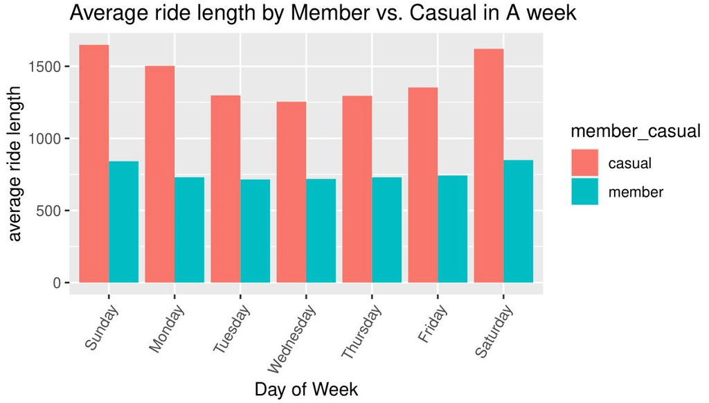

Average ride length by riders

## ACT

Based on analysis, the following recommendations are provided to apply on the marketing strategies to convert casual riders into member riders.